# Narrativa de Datos: Penetración Tecnológica en Hogares de Montevideo

Análisis de la Encuesta Continua de Hogares (ECH) 2019 del INE Uruguay: ¿qué relación existe entre la suscripción a TV por cable, el nivel socioeconómico, la edad, el sexo y los ingresos de los hogares de Montevideo?

Este notebook es la capa de *reporte*: toda la lógica de carga, limpieza, cálculo y graficado vive en el paquete `narrativa_datos`, con sus propios tests unitarios en `tests/`. Aquí solo se llama a esas funciones y se narra el análisis.

**Fuente:** Instituto Nacional de Estadística (INE) - Encuesta Continua de Hogares (ECH), Año 2019.

> Los datos utilizados son solo un extracto realizado con fines académicos, no una muestra representativa completa ni un estudio oficial del INE.

|  | id_hogar | departamento | barrio | tipo_abonado | estrato_tipo | total_personas | tiene_internet | internet_fija | internet_movil | tiene_pc | ... | muros_agrietados | puertas_ventanas_deterioradas | grietas_pisos | caida_revoque | cielorraso_desprendido | poca_luz_solar | escasa_ventilacion | se_inunda | peligro_derrumbe | humedad_cimientos |
| --- | --- | --- | --- | --- | --- | --- | --- | --- | --- | --- | --- | --- | --- | --- | --- | --- | --- | --- | --- | --- | --- |
| 0 | 2019000001 | ROCHA |  | 1.0 | 8.0 | 2.0 | 2.0 | 0.0 | 0.0 | 2.0 | ... | 2.0 | 2.0 | 2.0 | 2.0 | 2.0 | 2.0 | 2.0 | 2.0 | 2.0 | 1.0 |
| 1 | 2019000002 | SALTO |  | 1.0 | 9.0 | 2.0 | 2.0 | 0.0 | 0.0 | 2.0 | ... | 2.0 | 2.0 | 2.0 | 2.0 | 2.0 | 2.0 | 2.0 | 2.0 | 2.0 | 2.0 |
| 2 | 2019000003 | MONTEVIDEO | Ituzaingo | 2.0 | 2.0 | 2.0 | 2.0 | 0.0 | 0.0 | 1.0 | ... | 2.0 | 2.0 | 2.0 | 1.0 | 2.0 | 2.0 | 2.0 | 2.0 | 2.0 | 1.0 |
| 3 | 2019000004 | MONTEVIDEO | Cordon | 1.0 | 4.0 | 2.0 | 1.0 | 1.0 | 2.0 | 1.0 | ... | 2.0 | 2.0 | 2.0 | 1.0 | 2.0 | 2.0 | 2.0 | 2.0 | 2.0 | 2.0 |
| 4 | 2019000005 | CANELONES |  | 1.0 | 8.0 | 4.0 | 1.0 | 1.0 | 2.0 | 1.0 | ... | 2.0 | 2.0 | 2.0 | 2.0 | 2.0 | 2.0 | 2.0 | 2.0 | 2.0 | 2.0 |

5 rows × 28 columns

## 1. Preparación de datos

Filtramos los hogares de Montevideo y clasificamos su nivel económico según el estrato socioeconómico (`estrato_tipo`, 1=bajo a 5=alto). Este estrato no es un cálculo de ingreso del hogar: es el **estrato socioeconómico de muestreo** que el INE define por zona para diseñar la muestra de la encuesta, antes de relevar a cada hogar. Lo usamos como proxy del nivel económico porque está directamente asociado al ingreso, pero conviene tener clara esta distinción.

|  | id_hogar | departamento | barrio | tipo_abonado | estrato_tipo | total_personas | tiene_internet | internet_fija | internet_movil | tiene_pc | ... | puertas_ventanas_deterioradas | grietas_pisos | caida_revoque | cielorraso_desprendido | poca_luz_solar | escasa_ventilacion | se_inunda | peligro_derrumbe | humedad_cimientos | nivel_economico |
| --- | --- | --- | --- | --- | --- | --- | --- | --- | --- | --- | --- | --- | --- | --- | --- | --- | --- | --- | --- | --- | --- |
| 2 | 2019000003 | MONTEVIDEO | Ituzaingo | 2.0 | 2.0 | 2.0 | 2.0 | 0.0 | 0.0 | 1.0 | ... | 2.0 | 2.0 | 1.0 | 2.0 | 2.0 | 2.0 | 2.0 | 2.0 | 1.0 | 2-Medio-Bajo |
| 3 | 2019000004 | MONTEVIDEO | Cordon | 1.0 | 4.0 | 2.0 | 1.0 | 1.0 | 2.0 | 1.0 | ... | 2.0 | 2.0 | 1.0 | 2.0 | 2.0 | 2.0 | 2.0 | 2.0 | 2.0 | 4-Medio-Alto |
| 7 | 2019000008 | MONTEVIDEO | Pocitos | 1.0 | 5.0 | 1.0 | 1.0 | 1.0 | 1.0 | 1.0 | ... | 2.0 | 2.0 | 2.0 | 2.0 | 2.0 | 2.0 | 2.0 | 2.0 | 2.0 | 5-Alto |
| 11 | 2019000012 | MONTEVIDEO | Punta Carretas | 2.0 | 5.0 | 1.0 | 2.0 | 0.0 | 0.0 | 1.0 | ... | 1.0 | 2.0 | 2.0 | 2.0 | 2.0 | 2.0 | 2.0 | 2.0 | 2.0 | 5-Alto |
| 13 | 2019000017 | MONTEVIDEO | Bañados de Carrasco | 1.0 | 2.0 | 4.0 | 1.0 | 2.0 | 1.0 | 1.0 | ... | 2.0 | 2.0 | 2.0 | 2.0 | 1.0 | 1.0 | 2.0 | 2.0 | 1.0 | 2-Medio-Bajo |

5 rows × 29 columns

## 2. Análisis preliminar

¿Cuántos hogares tienen cable? Contamos el total de hogares relevados en Montevideo y qué proporción de ellos está abonada a TV cable.

```
Estudiados: 15628 hogares en Montevideo.
9518 tienen TV cable (60.9%).
6110 no tienen TV cable (39.1%).
```

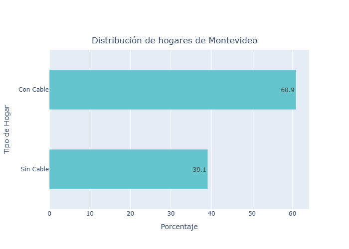

## 3. Distribución de abonados por barrio

Calculamos el % de hogares con cable en cada barrio de Montevideo, y los clasificamos en cuatro niveles de suscripción según los cuartiles de esa distribución: cada cuartil marca el corte que separa un 25% de los barrios del siguiente, ordenados de menor a mayor % de abonados.

Estos son los cortes reales, calculados sobre los 62 barrios, y la clasificación que definen:

- **1-Baja**: hasta 54,19% de hogares abonados
- **2-Media-Baja**: entre 54,19% y 59,39%
- **3-Media-Alta**: entre 59,39% y 65,40%
- **4-Alta**: más de 65,40%

El siguiente cálculo confirma esos mismos cortes sobre los datos:

```
0.25    54.1850
0.50    59.3850
0.75    65.3975
Name: Porcentaje abonado, dtype: float64
```

¿Qué barrios tienen mayor y menor nivel de suscripción (% de abonados)?

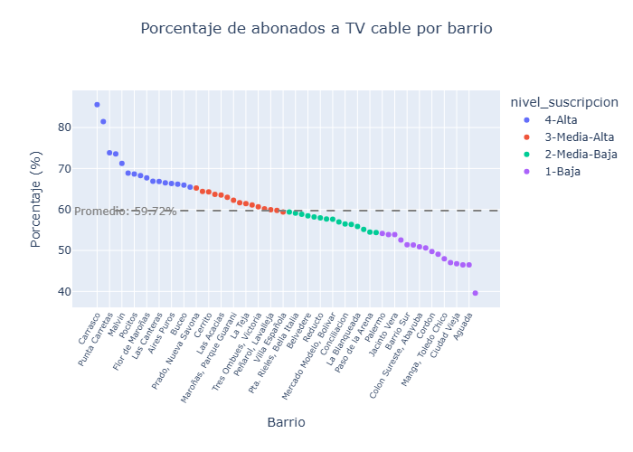

### Relación entre nivel de suscripción y nivel económico

¿Qué relación hay entre el nivel de suscripción del barrio y el nivel económico de los hogares abonados?

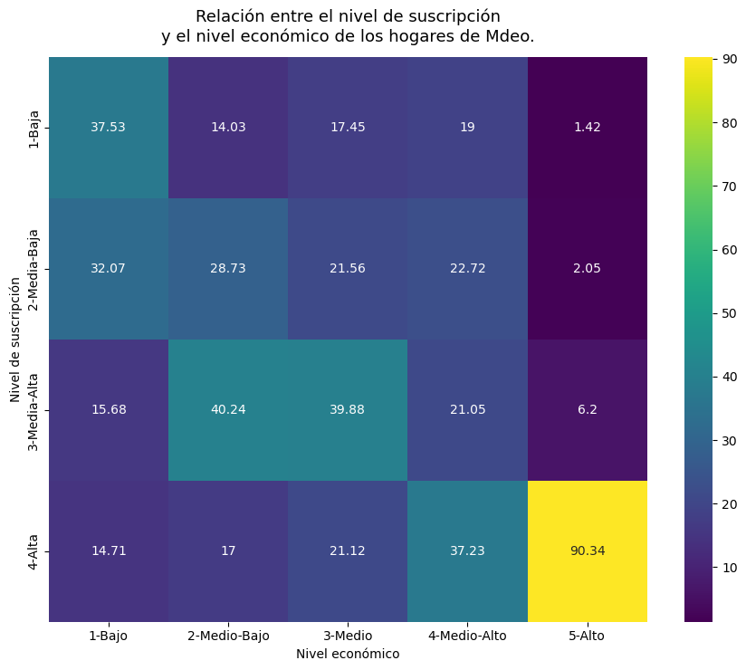

## 4. Composición de los hogares con y sin cable

- ¿Cuál es el promedio de edades?
- ¿Cuál es la composición por sexo?

Para comparar, cada hogar se clasifica cruzando dos variables: si **ese hogar** tiene o no cable, y el **nivel de suscripción de su barrio** (el mismo cuartil de la sección 3 — una característica del barrio, no del hogar individual). Por eso puede haber hogares "Sin cable" en un barrio de "Alta suscripción": son la excepción dentro de un barrio donde la mayoría de los hogares sí está abonada.

|  | id_hogar | departamento | barrio | tipo_abonado | estrato_tipo | total_personas | tiene_internet | internet_fija | internet_movil | tiene_pc | ... | nivel_economico | nivel_suscripcion | id_persona | sexo | edad | ingresos_personales | condicion_actividad_cod | tiene_celular_persona | edad_grupo | sexo_grupo |
| --- | --- | --- | --- | --- | --- | --- | --- | --- | --- | --- | --- | --- | --- | --- | --- | --- | --- | --- | --- | --- | --- |
| 0 | 2019000003 | MONTEVIDEO | Ituzaingo | Sin cable | 2.0 | 2.0 | 2.0 | 0.0 | 0.0 | 1.0 | ... | 2-Medio-Bajo | 3-Media-Alta | 1.0 | 2.0 | 32.0 | 23968.0 | 2.0 | 1.0 | 2-Adultos | 2-Mujer |
| 1 | 2019000003 | MONTEVIDEO | Ituzaingo | Sin cable | 2.0 | 2.0 | 2.0 | 0.0 | 0.0 | 1.0 | ... | 2-Medio-Bajo | 3-Media-Alta | 2.0 | 1.0 | 9.0 | 0.0 | 1.0 | 2.0 | 1-Niños-Jovenes | 1-Hombre |
| 2 | 2019000004 | MONTEVIDEO | Cordon | Con cable | 4.0 | 2.0 | 1.0 | 1.0 | 2.0 | 1.0 | ... | 4-Medio-Alto | 1-Baja | 1.0 | 2.0 | 53.0 | 53662.0 | 2.0 | 1.0 | 2-Adultos | 2-Mujer |
| 3 | 2019000004 | MONTEVIDEO | Cordon | Con cable | 4.0 | 2.0 | 1.0 | 1.0 | 2.0 | 1.0 | ... | 4-Medio-Alto | 1-Baja | 2.0 | 2.0 | 13.0 | 0.0 | 1.0 | 1.0 | 1-Niños-Jovenes | 2-Mujer |
| 4 | 2019000008 | MONTEVIDEO | Pocitos | Con cable | 5.0 | 1.0 | 1.0 | 1.0 | 1.0 | 1.0 | ... | 5-Alto | 4-Alta | 1.0 | 2.0 | 85.0 | 73500.0 | 10.0 | 1.0 | 3-Adultos_mayores | 2-Mujer |

5 rows × 38 columns

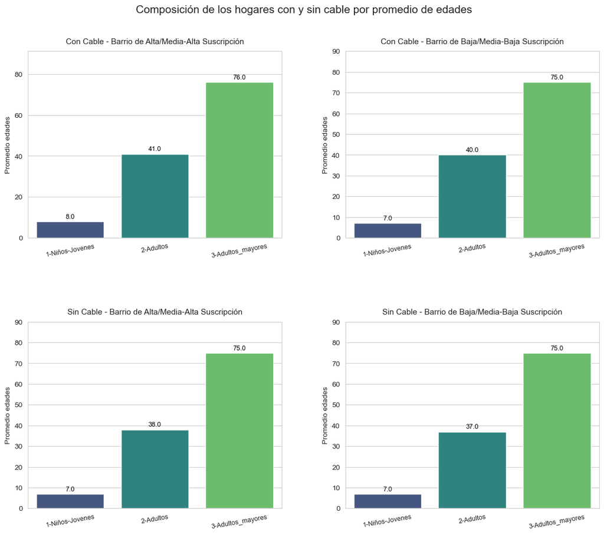

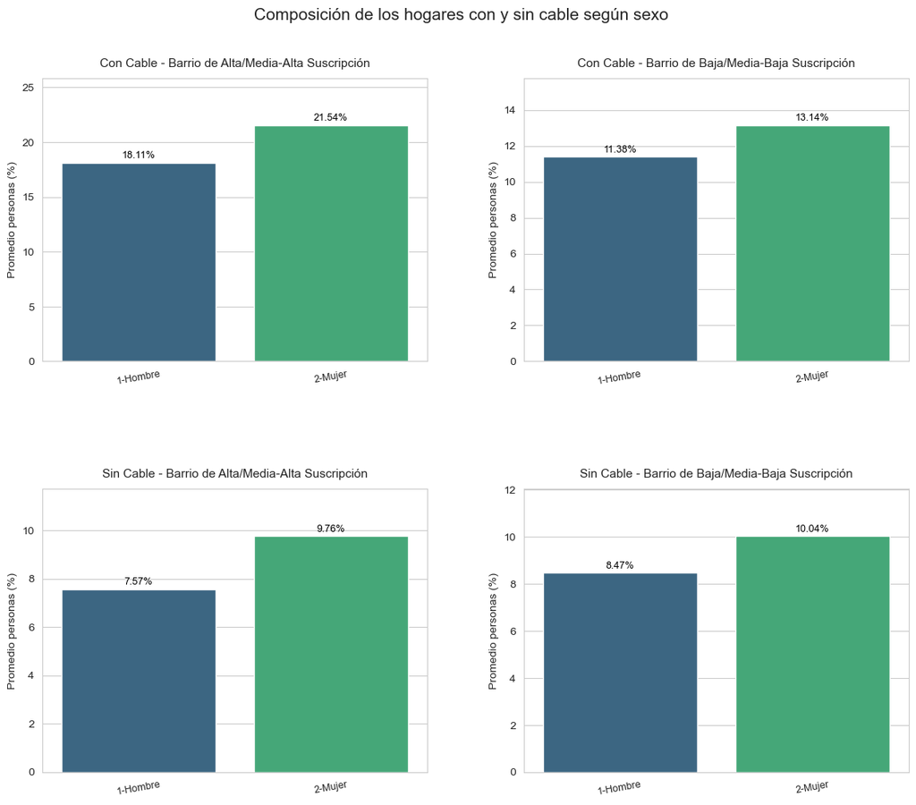

## 5. Ampliación del análisis

El análisis anterior se centró en la relación entre suscripción a TV cable, barrio y nivel económico. Los datos de la ECH permiten ir más allá. Esta sección se organiza en tres entornos temáticos:

- **Entorno 1 — Nivel económico del hogar**: brecha digital y acceso a tecnología, usando la escala de 5 niveles económicos.
- **Entorno 2 — Nivel de pobreza del hogar**: el mismo acceso a tecnología, pero visto según si el hogar está por debajo de la línea de pobreza.
- **Entorno 3 — Otros factores del hogar y el territorio**: sustitución tecnológica, vivienda, composición del hogar, situación ocupacional y alcance geográfico nacional.

*Nota metodológica: se evaluó también el nivel educativo del hogar como posible métrica, pero se descartó — la ECH no tiene una variable única de "nivel educativo alcanzado"; construirla exigiría derivarla de ~7 variables de asistencia/finalización por nivel, con riesgo de introducir un criterio metodológico no oficial. Se prefirió no incluir una métrica poco confiable.*

|  | tiene_cable | tiene_internet | tiene_pc | tiene_streaming | pobre | indice_carencias_vivienda |
| --- | --- | --- | --- | --- | --- | --- |
| 2 | False | False | True | False | False | 3 |
| 3 | True | True | True | False | False | 1 |
| 7 | True | True | True | False | False | 0 |
| 11 | False | False | True | False | False | 2 |
| 13 | True | True | True | False | False | 4 |

### Entorno 1: Nivel económico del hogar

Agrupando los hogares en 5 niveles económicos (1-Bajo a 5-Alto).

#### 5.1 Brecha digital ampliada: más allá de la TV cable

La TV cable es solo una de varias tecnologías del hogar. ¿Cómo se compara su penetración por nivel económico con la de Internet, PC y streaming?

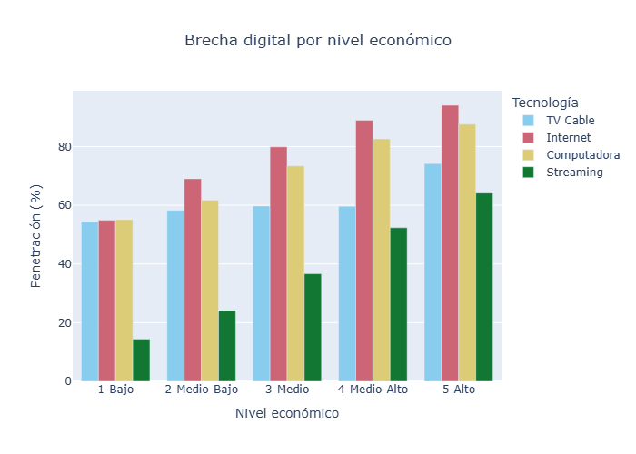

#### 5.2 Acceso a cable, Internet y celular según nivel económico

¿El acceso a cada tecnología varía de la misma forma según el nivel económico del hogar?

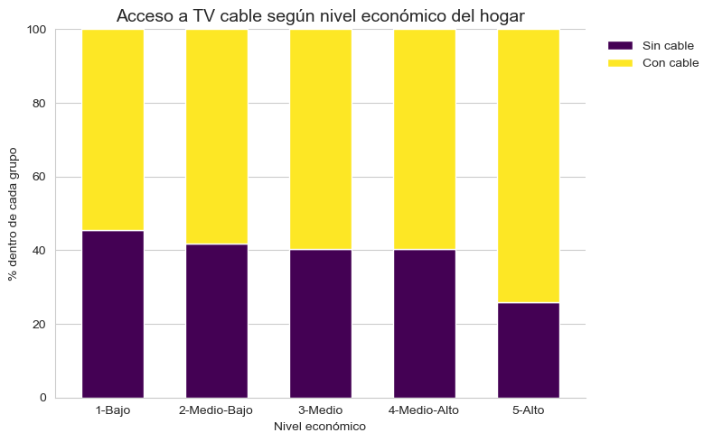

**Internet**

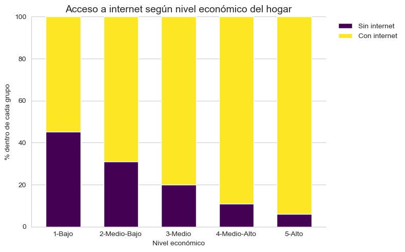

**Telefonía celular**

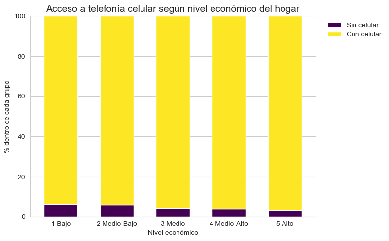

#### 5.3 Ingreso del hogar y conectividad a TV cable

¿Los hogares con TV cable tienen, en promedio, mayores ingresos que los que no la tienen? Comparamos directamente el ingreso típico del hogar entre ambos grupos.

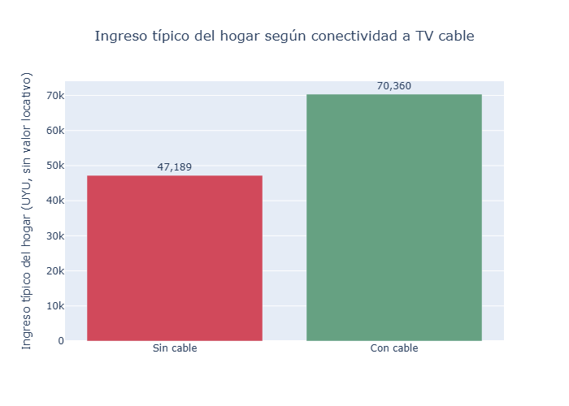

### Entorno 2: Nivel de pobreza del hogar

El nivel económico (Entorno 1) es una escala de 5 niveles. La pobreza es distinta: una clasificación binaria (Pobre / No pobre) según si el hogar está por debajo de la línea de pobreza (metodología INE 2006). Son medidas relacionadas pero no intercambiables — un hogar puede ser "No pobre" y aun así estar en el nivel económico más bajo de la escala de 5.

#### 5.4 Acceso a cable, Internet y celular según condición de pobreza

¿Los hogares pobres tienen menos acceso a cada tecnología que los no pobres?

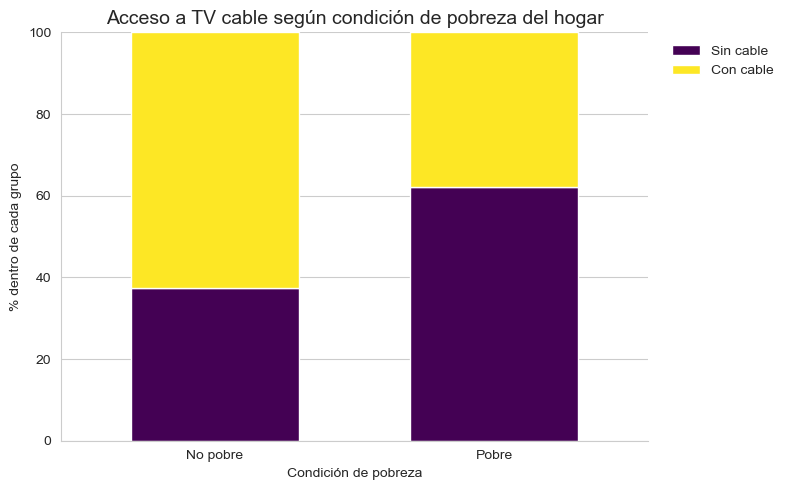

**Internet**

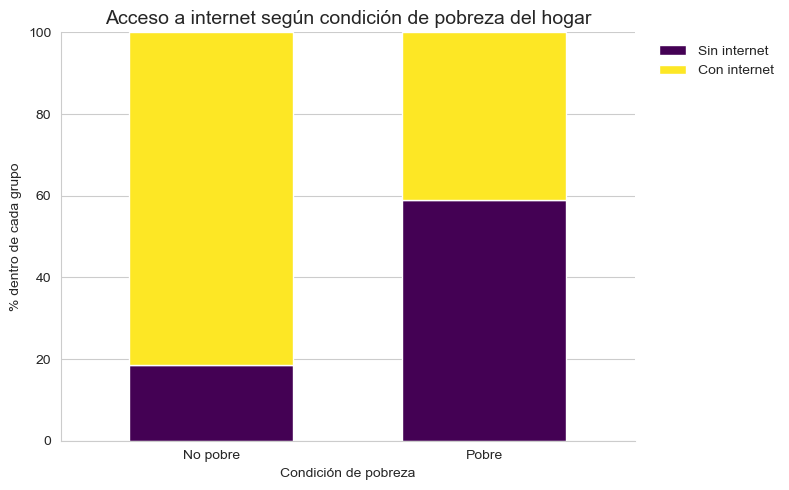

**Telefonía celular**

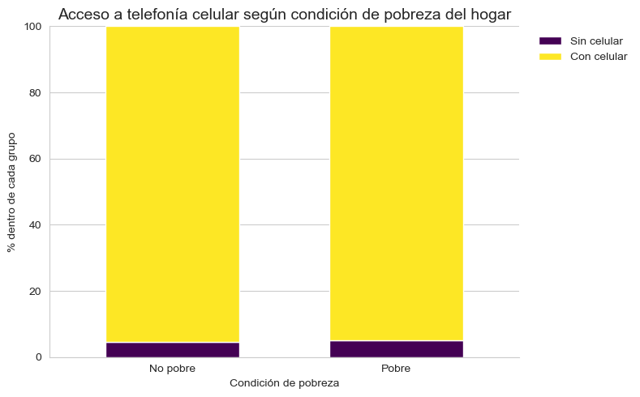

### Entorno 3: Otros factores del hogar y el territorio

#### 5.5 Sustitución tecnológica: streaming y TV cable

¿El streaming sustituye a la TV cable? Hipótesis: los hogares con streaming tendrían menos probabilidad de tener cable.

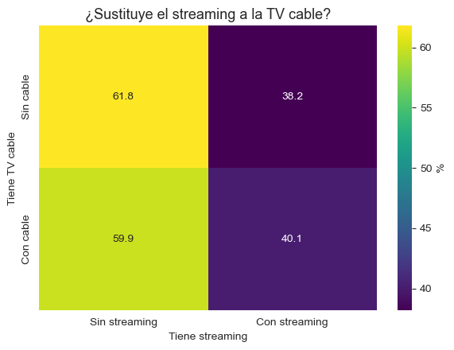

#### 5.6 TV cable según tipo de conexión a internet

¿Los hogares con cable tienden a tener también un tipo particular de conexión a internet?

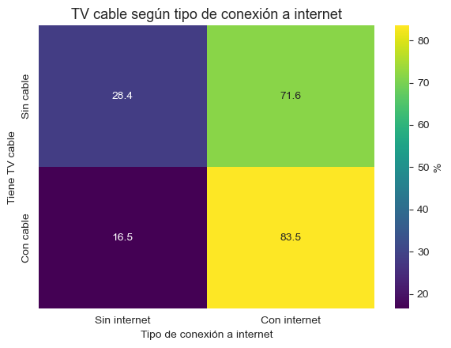

#### 5.7 Condiciones estructurales de la vivienda

¿Cuáles son las condiciones de la vivienda en los hogares con acceso a celular, streaming o internet?

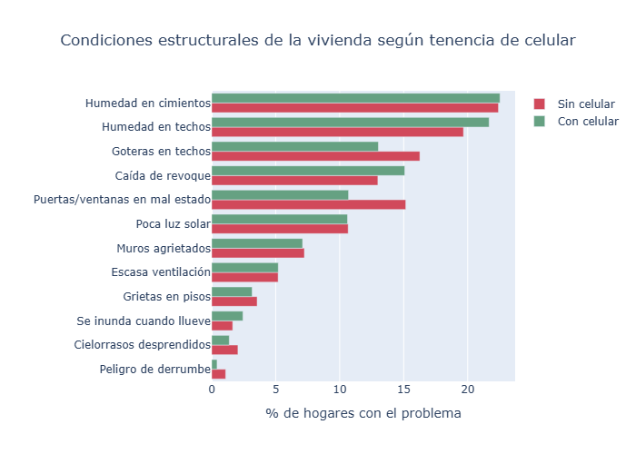

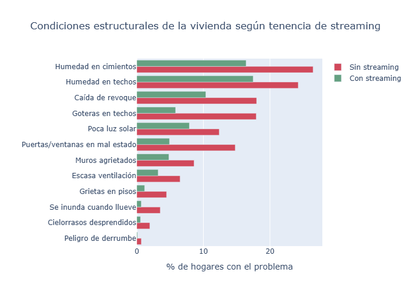

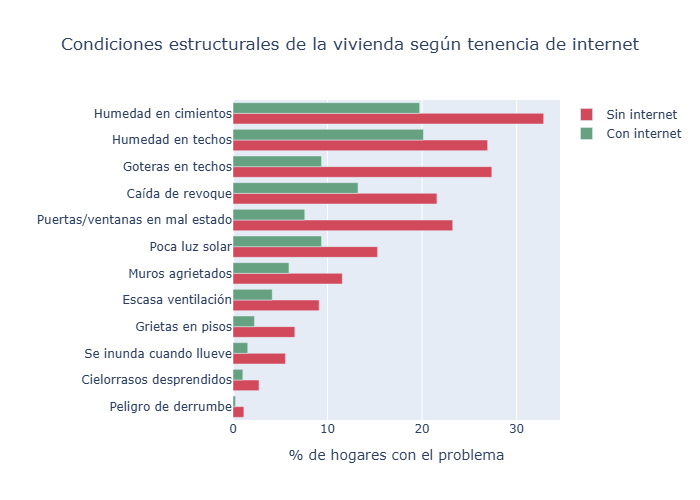

#### 5.7.1 Síntesis: diferencia entre celular, streaming e internet

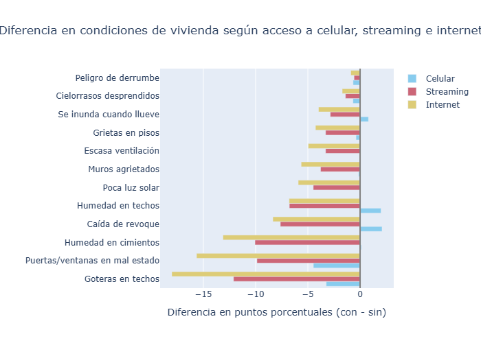

#### 5.8 Composición del hogar según conectividad

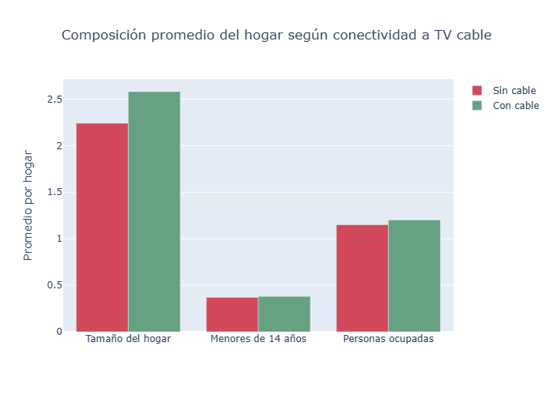

#### 5.9 Situación ocupacional según conectividad

Usando `pobpcoac` (población por condición de actividad), colapsada en Ocupados / Desocupados / Inactivos (excluyendo menores de 14 años, que no integran la fuerza laboral), comparada según tipo de abonado, acceso a celular y acceso a internet.

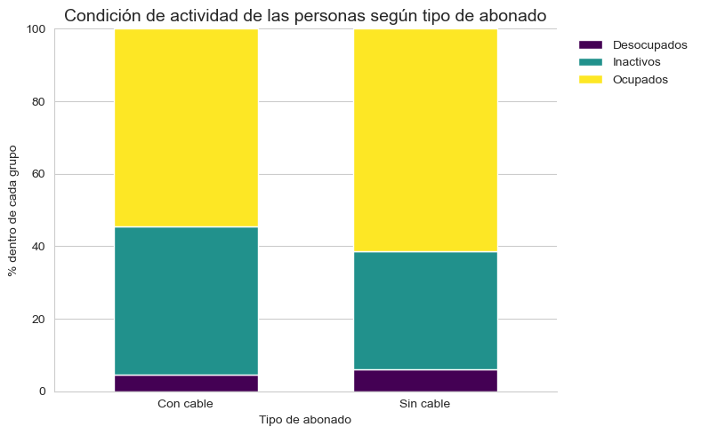

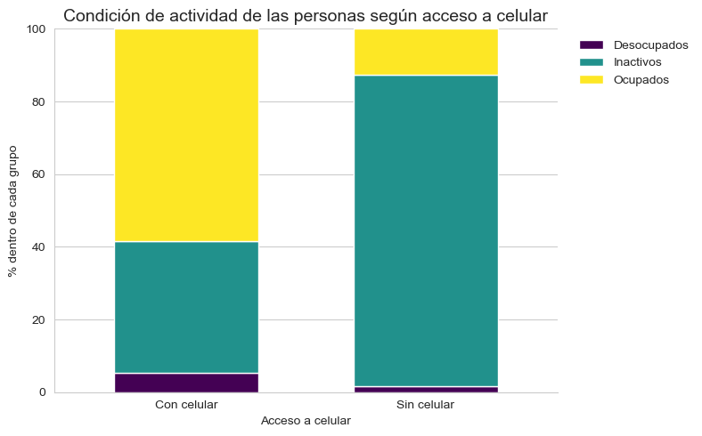

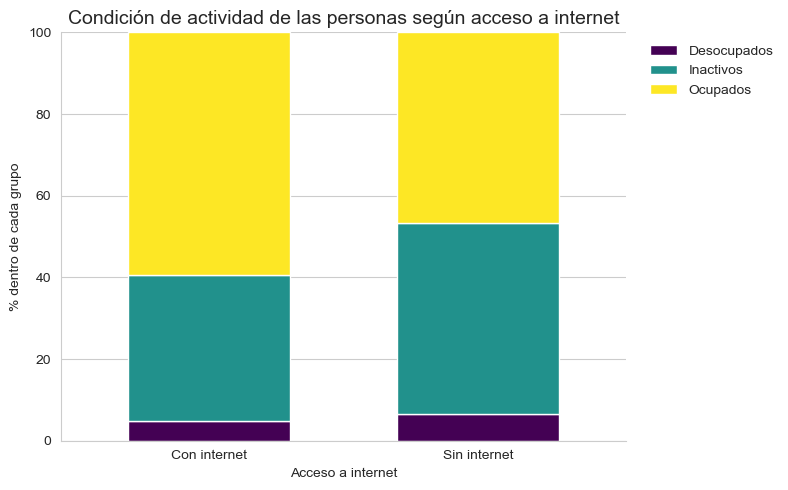

#### 5.10 Alcance nacional: penetración por departamento

Todo el análisis anterior se limitó a Montevideo. La ECH cubre los 19 departamentos de Uruguay — ¿cómo se compara Montevideo con el resto del país?

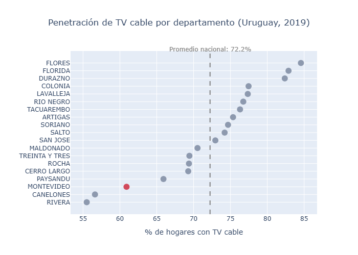

## 6. Resumen analítico final

**Contexto.** Uruguay, 2019. La Encuesta Continua de Hogares releva a 15.628 hogares de Montevideo (y a los 42.507 hogares elegibles de todo el país). El 60,9% de los hogares montevideanos tiene TV cable — pero esa cifra promedio esconde brechas importantes.

### Entorno 1 — Nivel económico

**La brecha no es uniforme entre tecnologías.** La penetración de TV cable varía moderadamente entre niveles económicos (54,5% en el nivel bajo vs. 74,2% en el alto — 20 puntos de diferencia). La brecha de **Internet** es mucho más marcada: 54,9% en el nivel bajo frente a 94,1% en el alto — casi 40 puntos. La TV cable, tecnología más antigua y con más operadores compitiendo en precio, se distribuye de forma más pareja que el acceso a Internet, que sigue siendo un bien más asociado al nivel económico del hogar.

**La telefonía celular es la excepción: ya es prácticamente universal.** A diferencia del cable y de Internet, el acceso a celular casi no varía según el nivel económico: 93,8% de los hogares de nivel económico bajo lo tiene, frente a 96,7% en los de nivel económico alto — apenas 3 puntos de diferencia.

### Entorno 2 — Nivel de pobreza

**La pobreza agudiza el mismo patrón, y confirma que el celular es distinto.** Solo el 6,7% de los hogares de Montevideo son pobres según la línea de pobreza del INE (metodología 2006). Entre ellos, el acceso a cada tecnología muestra el mismo orden que por nivel económico, pero más marcado: el 37,8% de los hogares pobres tiene TV cable, frente al 62,6% de los no pobres (25 puntos). En Internet la brecha es mayor: 41,1% de los hogares pobres lo tienen, contra 81,6% de los no pobres (40 puntos). En cambio, el celular casi no distingue: 95,0% de los hogares pobres lo tienen, prácticamente igual que el 95,3% de los no pobres. Esto es consistente con lo visto en las condiciones de vivienda: casi no hay diferencia habitacional entre hogares con y sin celular, mientras que sí la hay (y marcada) entre hogares con y sin streaming. El celular parece haberse convertido en un bien de primera necesidad, ajeno a la pobreza o el nivel económico; el cable e Internet, no tanto. Las carencias habitacionales confirman el mismo patrón para el cable: los hogares sin cable presentan, en promedio, más problemas estructurales de vivienda (humedad, goteras, grietas) — el índice de carencias habitacionales promedia 1,42 en hogares sin cable contra 0,95 en hogares con cable. El ingreso del hogar sigue el mismo patrón: el valor típico es considerablemente más alto en los hogares con cable.

### Entorno 3 — Otros factores del hogar y el territorio

**El streaming no sustituye a la TV cable — más bien la acompaña.** Contrario a una hipótesis intuitiva de "sustitución tecnológica", los hogares con cable tienen streaming en una proporción similar (40,1%) a los que no tienen cable (38,2%). Y los hogares con cable tienen más probabilidad de tener Internet (83,5% vs. 71,6%). Esto sugiere que el cable, el streaming y el Internet son en gran medida **complementarios** dentro de los hogares de mayor poder adquisitivo, más que sustitutos entre sí.

**La composición del hogar y la situación laboral muestran diferencias más sutiles.** Los hogares con cable son levemente más grandes (2,58 vs. 2,24 personas). La desocupación es algo mayor en los hogares sin cable (6,1% vs. 4,6%), mientras que los hogares con cable tienen más personas inactivas (40,8% vs. 32,4%) — compatible con una mayor presencia de jubilados o rentistas, grupos con más estabilidad económica.

**El dato más contraintuitivo: Montevideo no es líder en penetración de TV cable.** Departamentos como Flores (84,6%), Florida (82,9%), Durazno (82,4%) y Colonia (77,5%) superan ampliamente el 60,9% de Montevideo. La capital, pese a concentrar mayor actividad económica, queda por debajo del promedio nacional en esta tecnología específica — una hipótesis a explorar en trabajo futuro es la mayor disponibilidad de alternativas (streaming, antena digital abierta, mejor cobertura de internet) en la capital frente al interior.

**Conclusión.** La narrativa inicial (penetración de TV cable asociada al nivel económico del barrio) se sostiene y se profundiza: la brecha de acceso a tecnología en Montevideo no es exclusiva del cable, es más aguda en Internet, se repite (y se agudiza) al mirar la pobreza en vez del nivel económico, y prácticamente desaparece en telefonía celular. Al mismo tiempo, el alcance nacional matiza la historia metropolitana: la brecha tecnológica en Uruguay no sigue un patrón simple de "capital vs. interior".

*Fuente: Instituto Nacional de Estadística (INE) - Encuesta Continua de Hogares (ECH), Año 2019.*